# Tutorial su API di Flickr

**Corso**: Social Media Management

**Docente**: Antonino Furnari

## Introduzione

Flickr è un servizio di hosting immagini e video americano, nonché una comunità online, ed è popolare perché al suo interno ospita foto ad alta risoluzione di fotografi dilettanti e professionisti.  
È stato creato da Ludicorp nel 2004, ma ha cambiato proprietà più volte ed è di proprietà di SmugMug dal 20 aprile 2018.  
Gli utenti di Flickr possono etichettare le immagini caricate con titoli, descrizioni e tag. Questi ultimi possono essere aggiunti successivamente sia dall'autore che da altri utenti (solo se autorizzati). I componenti citati precedentemente sono di fondamentale importanza perché permettono di ricercare una immagine.  
Un'altra funzionalità di Flickr è quella che permette di controllare chi ha il diritto di vedere le foto, rendendo le proprie foto pubbliche o private. Inoltre, all'interno della categoria "privata" è possibile distinguere quelle che possono essere visualizzate dai contatti considerati amici, solo dai familiari oppure solo da sé stessi.

[Documentazione Flickr API](https://www.flickr.com/services/api)  
Per sfruttare la maggior parte delle API di Flickr è necessario l'utilizzo di un token e questo è possibile solo tramite l'utilizzo di OAuth.

## Profilo e Applicazione

### Creazione di un profilo utente

Prima di tutto è necessario creare un proprio profilo utente e per farlo basta dirigersi al seguente link: https://identity.flickr.com/sign-up

La schermata che vedremo è la seguente:

[figure not shown]

Basterà inserire i dati richiesti e dopo aver cliccato su "Registrati" avremo accesso al nostro profilo.

[figure not shown]

### Creazione di un'applicazione

A questo punto per poter utilizzare le API è necessario creare un'applicazione usando il seguente link: https://www.flickr.com/services/apps/create/  
Successivamente, bisogna cliccare su "Richiedi una chiave API"

[figure not shown]

Adesso bisogna scegliere se l'applicazione è commerciale oppure no.

[figure not shown]

In base alla scelta bisognerà dare alcune informazioni riguardo l'uso che farete dell'applicazione e una volta aver compilato tutto, la vostra applicazione sarà visibile al seguente link: https://www.flickr.com/services/apps/by/me

[figure not shown]

Qui potete trovare l'**API key** e l'**API secret** che sono fondamentali per poter utilizzare le API di Flickr.

## Accesso alle API

### Utilizzo di OAuth con Flickr

OAuth è un protocollo aperto, semplice e sicuro che consente alle applicazioni di autenticare gli utenti e di interagire con Flickr per conto loro. Le informazioni dell’utente finale vengono trasferite in modo sicuro, senza rivelarne l’identità. In Flickr utilizziamo il protocollo OAuth per verificare che l’applicazione interagisca con Flickr per conto tuo nel rispetto delle autorizzazioni che hai concesso.

### Codice utile

In questa sezione saranno spiegate tutte le funzioni utili che serviranno per poter procedere con il tutorial sull'uso delle API di Flickr.

Nel seguente blocco di codice sono presenti due variabili globali che sono l'API key (KEY) e l'API secret (SECRET), queste si trovano nella pagine delle applicazioni di Flickr.

```python
# Flickr api key
KEY:str = "<API-KEY>"

# Flickr api secret
SECRET:str = "<API-SECRET>"
```

Le due funzioni successive sono necessarie per poter generare un **oauth_nonce**, che è un valore utilizzato per associare una sessione client a un token ID e per mitigare gli attacchi di riproduzione. Questo valore deve essere unico per tutte le richieste HTTP.

```python
from datetime import datetime
import time
import random
import sys
from hashlib import sha1, md5

def microtime(get_as_float = False):
    d = datetime.now()
    t = time.mktime(d.timetuple())
    if get_as_float:
        return t
    else:
        return '%d' % (t)

def mt_rand (low = 0, high = sys.maxsize):
    return random.randint(low, high)
```

```python
m = md5()
tmp = microtime() + str(mt_rand())
m.update(bytes(tmp, 'UTF-8'))
oauth_nonce = m.hexdigest()
print("oauth_nonce:", oauth_nonce)
```

```
oauth_nonce: f0dffbdec2fc969c1065bf904c78e5c9
```

A questo punto generiamo un **oauth_timestamp** necessario per la gestione del tempo di validazione del token. Anche questo valore deve essere unico, altrimenti il server negherà le richieste e invaliderà il token.

```python
oauth_timestamp = int(round(time.time() * 1000))
print("oauth_timestamp:", oauth_timestamp)
```

```
oauth_timestamp: 1610560881628
```

La funzione json_load è utile per leggere i JSON.

```python
import json
from urllib.request import urlopen as uRequest

def json_load(url):
    page = uRequest(url)
    return json.load(page)
```

La funzione send_requests è utile per mandare richieste http.

```python
def send_request(url):
    response = !curl -X GET "{url}"
    # Questo controllo è importante perché in base al sistema operativo curl ritorna due risposte differenti.
    # Nel caso di windows si ottiene una lista e quindi bisogna prendere l'ultimo valore
    # Nel caso di Linux si ottiene semplicemente una stringa quindi possiamo ritornare direttamente il valore
    if isinstance(response, list):
        response = response[-1:][0]
    return str(response)
```

La funzione extract_debug_sbs è una funzione che permette di estrarre una specifica sottostringa da una risposta http che vedremo in seguito.

```python
def extract_debug_sbs(text):
    return str(text.split("debug_sbs=")[1])
```

Per poter utilizzare le API è necessario sottoscrivere tutte le richieste e, al momento, Flickr supporta solo la crittografia della firma HMAC-SHA1. Questo perché tutte le richieste vengono effettuate tramite HTTP in modo non protetto.  
Per creare una firma valida bisogna utilizzare la seguente funzione:

```python
import base64
import hmac

def create_signature(url,secret = None):
    global SECRET
    if secret is None:
        secret = ""
    key = SECRET + "&" + secret
    hashkey = bytes(key, 'UTF-8')
    signature = hmac.new(hashkey, msg = bytes(url, 'UTF-8'), digestmod = sha1)
    r = str(base64.urlsafe_b64encode(signature.digest()), 'UTF-8')
    r = r.replace("-", "%2B")
    r = r.replace("_", "%2F")
    return r
```

A questo punto è possibile procedere con il flusso di autorizzazione di OAuth di Flickr che prevede 3 passaggi:

- **Ottenere un token di richiesta**
- **Ottenere l'autorizzazione dell'utente**
- **Scambiare il token di richiesta con un token di accesso**

### Ottenere un token di richiesta

Analizziamo l'URL per il token di richiesta.

```python
url = "https://www.flickr.com/services/oauth/request_token\
?oauth_nonce=" + str(oauth_nonce) + "\
&oauth_timestamp=" + str(oauth_timestamp) + "\
&oauth_consumer_key=" + KEY + "\
&oauth_signature_method=HMAC-SHA1\
&oauth_version=1.0\
&oauth_callback=http://www.example.com\
&oauth_signature="
```

I parametri dell'URL sono i seguenti:

- oauth_nonce: valore utilizzato per associare una sessione client a un token ID e per mitigare gli attacchi di riproduzione;
- oauth_timestamp: necessario per la gestione del tempo di validazione del token;
- oauth_consumer_key: API key di flickr;
- oauth_signature_method: HMAC-SHA1, che è l'unico supportato da Flickr;
- oauth_version: 1.0, che indica la versione di OAuth usata da Flickr;
- oauth_callback: sito da visualizzare dopo aver correttamente ottenuto l'autorizzazione, in generale potete usare qualunque sito;
- oauth_signature: la firma della richiesta che è sempre diversa.

Usiamo la funzione send_request e quello che otterremo è un oauth_problem, che è corretto, perché ancora non è stata inserita la firma.

```python
result = send_request(url)
result
```

```
'oauth_problem=signature_invalid&debug_sbs=GET&https%3A%2F%2Fwww.flickr.com%2Fservices%2Foauth%2Frequest_token&oauth_callback%3Dhttp%253A%252F%252Fwww.example.com%26oauth_consumer_key%3D0b37fb5cffe4a0ac33ce259b47ba63f5%26oauth_nonce%3Df0dffbdec2fc969c1065bf904c78e5c9%26oauth_signature_method%3DHMAC-…
```

A questo punto, usando la funzione extract_debug_sbs, estraiamo tutto ciò che è scritto dopo *debug_sbs=*

```python
debug_sbs = str(extract_debug_sbs(result))
debug_sbs
```

```
'GET&https%3A%2F%2Fwww.flickr.com%2Fservices%2Foauth%2Frequest_token&oauth_callback%3Dhttp%253A%252F%252Fwww.example.com%26oauth_consumer_key%3D0b37fb5cffe4a0ac33ce259b47ba63f5%26oauth_nonce%3Df0dffbdec2fc969c1065bf904c78e5c9%26oauth_signature_method%3DHMAC-SHA1%26oauth_timestamp%3D1610560881628%26o…
```

Usiamo la funzione create_signature passando debug_sbs e creiamo una oauth_signature.

```python
oauth_signature = create_signature(debug_sbs)
oauth_signature
```

```
'sWeVUK7C2COTT0VHkFqF5oyWxcs='
```

A questo punto la firma generata sarà inserita nell'apposito parametro oauth_signature.

```python
url = "https://www.flickr.com/services/oauth/request_token\
?oauth_nonce=" + str(oauth_nonce) + "\
&oauth_timestamp=" + str(oauth_timestamp) + "\
&oauth_consumer_key=" + KEY + "\
&oauth_signature_method=HMAC-SHA1\
&oauth_version=1.0\
&oauth_callback=http://www.example.com\
&oauth_signature=" + str(oauth_signature)
```

Richiamiamo la funzione send_request ed estraiamo l'oauth_token e l'oauth_token_secret.

```python
import re

result = send_request(url)
oauth_token = str(re.search(r"(oauth_token=[0-9-a-z]+)", result).group().split("=")[1])
oauth_token_secret = str(re.search(r"(oauth_token_secret=[0-9-a-z]+)", result).group().split("=")[1])
print("oauth_token =", oauth_token)
print("oauth_token_secret =", oauth_token_secret)
result
```

```
oauth_token = 72157717877602972-3bab46de8d45620f
oauth_token_secret = f9340aa97c9a79c6
```

```
'oauth_callback_confirmed=true&oauth_token=72157717877602972-3bab46de8d45620f&oauth_token_secret=f9340aa97c9a79c6'
```

Siamo riusciti ad ottenere un token di richiesta e possiamo passare alla fase successiva.

### Ottenere l'autorizzazione dell'utente

Nel pezzo di codice sottostante bisogna utilizzare l'oauth_token ottenuto nella fase precedente. Una volta eseguito sarete reindirizzati alla seguente pagina, dove bisognerà cliccare su "AUTORIZZO".

[figure not shown]

Al termine della procedura di autorizzazione, Flickr vi reindirizza al parametro oauth_callback specificato nella fase precedente.

[figure not shown]

Successivamente bisognerà inserire l'oauth_verifier come input, quest'ultimo è reperibile nella barra dell'url del vostro browser.

```python
import webbrowser

webbrowser.open("https://www.flickr.com/services/oauth/authorize?oauth_token="+oauth_token)
oauth_verifier = str(input('oauth_verifier: '))
oauth_verifier
```

```
oauth_verifier: c9cbfc1af09cc8ae
```

```
'c9cbfc1af09cc8ae'
```

### Scambiare il token di richiesta con un token di accesso

Una volta ottenuta l’autorizzazione per l’applicazione, è possibile scambiare il token di richiesta approvato con un token di accesso. Questo token di accesso deve essere memorizzato dalla tua applicazione e utilizzato per effettuare richieste autorizzate a Flickr.  
Analizziamo la richiesta di token di accesso.

```python
url = "https://www.flickr.com/services/oauth/access_token\
?oauth_nonce=" + str(oauth_nonce) + "\
&oauth_timestamp=" + str(oauth_timestamp) + "\
&oauth_verifier=" + str(oauth_verifier) + "\
&oauth_consumer_key=" + KEY + "\
&oauth_signature_method=HMAC-SHA1\
&oauth_version=1.0\
&oauth_token=" + str(oauth_token) + "\
&oauth_signature="
```

I parametri dell'URL sono i seguenti:

- oauth_nonce: valore utilizzato per associare una sessione client a un token ID e per mitigare gli attacchi di riproduzione;
- oauth_timestamp: necessario per la gestione del tempo di validazione del token;
- oauth_verifier: ottenuto nella seconda fase;
- oauth_consumer_key: API key di flickr;
- oauth_signature_method: HMAC-SHA1, che è l'unico supportato da Flickr;
- oauth_version: 1.0, che indica la versione di OAuth usata da Flickr;
- oauth_token: ottenuto nella prima fase;
- oauth_signature: la firma della richiesta che è sempre diversa.

Usiamo la funzione send_request e quello che otterremo è un oauth_problem, che è corretto, perché ancora non è stata inserita la firma.

```python
result = send_request(url)
result
```

```
'oauth_problem=signature_invalid&debug_sbs=GET&https%3A%2F%2Fwww.flickr.com%2Fservices%2Foauth%2Faccess_token&oauth_consumer_key%3D0b37fb5cffe4a0ac33ce259b47ba63f5%26oauth_nonce%3Df0dffbdec2fc969c1065bf904c78e5c9%26oauth_signature_method%3DHMAC-SHA1%26oauth_timestamp%3D1610560881628%26oauth_token%3D…
```

A questo punto, usando la funzione extract_debug_sbs, estraiamo tutto ciò che è scritto dopo *debug_sbs=*

```python
debug_sbs = extract_debug_sbs(result)
debug_sbs
```

```
'GET&https%3A%2F%2Fwww.flickr.com%2Fservices%2Foauth%2Faccess_token&oauth_consumer_key%3D0b37fb5cffe4a0ac33ce259b47ba63f5%26oauth_nonce%3Df0dffbdec2fc969c1065bf904c78e5c9%26oauth_signature_method%3DHMAC-SHA1%26oauth_timestamp%3D1610560881628%26oauth_token%3D72157717877602972-3bab46de8d45620f%26oauth…
```

Usiamo la funzione create_signature passando sia debug_sbs che l'oauth_token_secret, ottenuto nella prima fase, e creiamo una oauth_signature.

```python
oauth_signature = create_signature(debug_sbs, oauth_token_secret)
oauth_signature
```

```
'igd5L%2FVlFqt9JLSNsY%2BOT9olHAs='
```

A questo punto la firma generata sarà inserita nell'apposito parametro oauth_signature.

```python
url = "https://www.flickr.com/services/oauth/access_token\
?oauth_nonce=" + str(oauth_nonce) + "\
&oauth_timestamp=" + str(oauth_timestamp) + "\
&oauth_verifier=" + str(oauth_verifier) + "\
&oauth_consumer_key=" + KEY + "\
&oauth_signature_method=HMAC-SHA1\
&oauth_version=1.0\
&oauth_token=" + str(oauth_token) + "\
&oauth_signature=" + str(oauth_signature)
```

Richiamiamo la funzione send_request ed estraiamo l'oauth_token e l'oauth_token_secret.

```python
result = send_request(url)
oauth_token = re.search("oauth_token=([0-9-a-z])+", result).group().split("=")[1]
oauth_token_secret = re.search("oauth_token_secret=([0-9-a-z])+", result).group().split("=")[1]
print("oauth_token =", oauth_token)
print("oauth_token_secret =", oauth_token_secret)
result
```

```
oauth_token = 72157717841954306-16977c886955a7bc
oauth_token_secret = bcce945a6247f898
```

```
'fullname=Luigi%20Seminara&oauth_token=72157717841954306-16977c886955a7bc&oauth_token_secret=bcce945a6247f898&user_nsid=190752071%40N07&username=seminara.luigi'
```

A Questo punto siamo riusciti ad ottenere un token di accesso per effettuare richieste autenticate alle API di Flickr.

## Utilizzo delle API RESTful

### flickr.test.login

Questo è un esempio banale di utilizzo delle API ed è un metodo di test che controlla se il chiamante è connesso, quindi restituisce il nome utente.  
Analizziamo la richiesta da effettuare.

```python
api = "https://www.flickr.com/services/rest\
?nojsoncallback=1\
&oauth_nonce=" + str(oauth_nonce) + "\
&format=json\
&oauth_consumer_key=" + KEY + "\
&oauth_timestamp=" + str(oauth_timestamp) + "\
&oauth_signature_method=HMAC-SHA1\
&oauth_version=1.0\
&oauth_token=" + oauth_token + "\
&method=flickr.test.login\
&oauth_signature="
```

I parametri della richiesta sono i seguenti:

- oauth_nonce: valore utilizzato per associare una sessione client a un token ID e per mitigare gli attacchi di riproduzione;
- format: che può essere json o XML, di default riceveremo un XML;
- oauth_consumer_key: API key di flickr;
- oauth_timestamp: necessario per la gestione del tempo di validazione del token;
- oauth_signature_method: HMAC-SHA1, che è l'unico supportato da Flickr;
- oauth_version: 1.0, che indica la versione di OAuth usata da Flickr;
- oauth_token: ottenuto nella terza fase;
- oauth_signature: la firma della richiesta che è sempre diversa.

Usiamo la funzione send_request e quello che otterremo è un oauth_problem, che è corretto, perché ancora non è stata inserita la firma.

```python
result = send_request(api)
result
```

```
'oauth_problem=signature_invalid&debug_sbs=GET&https%3A%2F%2Fwww.flickr.com%2Fservices%2Frest&format%3Djson%26method%3Dflickr.test.login%26nojsoncallback%3D1%26oauth_consumer_key%3D0b37fb5cffe4a0ac33ce259b47ba63f5%26oauth_nonce%3Df0dffbdec2fc969c1065bf904c78e5c9%26oauth_signature_method%3DHMAC-SHA1%…
```

A questo punto, usando la funzione extract_debug_sbs, estraiamo tutto ciò che è scritto dopo *debug_sbs=*

```python
debug_sbs = extract_debug_sbs(result)
debug_sbs
```

```
'GET&https%3A%2F%2Fwww.flickr.com%2Fservices%2Frest&format%3Djson%26method%3Dflickr.test.login%26nojsoncallback%3D1%26oauth_consumer_key%3D0b37fb5cffe4a0ac33ce259b47ba63f5%26oauth_nonce%3Df0dffbdec2fc969c1065bf904c78e5c9%26oauth_signature_method%3DHMAC-SHA1%26oauth_timestamp%3D1610560881628%26oauth_…
```

Usiamo la funzione create_signature passando sia debug_sbs che l'oauth_token_secret, ottenuto nella terza fase, e creiamo una oauth_signature.

```python
oauth_signature = create_signature(debug_sbs, oauth_token_secret)
oauth_signature
```

```
'Dd7UmKoc%2FxGhKkIflxvpvqxKXns='
```

A questo punto la firma generata sarà inserita nell'apposito parametro oauth_signature.

```python
api = "https://www.flickr.com/services/rest\
?nojsoncallback=1\
&oauth_nonce=" + str(oauth_nonce) + "\
&format=json\
&oauth_consumer_key=" + KEY + "\
&oauth_timestamp=" + str(oauth_timestamp) + "\
&oauth_signature_method=HMAC-SHA1\
&oauth_version=1.0\
&oauth_token=" + str(oauth_token) + "\
&method=flickr.test.login\
&oauth_signature=" + str(oauth_signature)
```

```python
send_request(api)
```

```
'{"user":{"id":"190752071@N07","username":{"_content":"seminara.luigi"},"path_alias":null},"stat":"ok"}'
```

Siamo riusciti ad ottenere una risposta da Flickr usando le API.

L'utilizzo delle API segue sempre lo stesso procedimento visto precedentemente, l'unica cosa che cambiano sono i parametri.  
La lista delle API di Flickr può essere consultata nel seguente link: https://www.flickr.com/services/api/

### flickr.photos.search

Restituisce un elenco di foto corrispondenti ad alcuni criteri. Verranno restituite solo le foto visibili all'utente chiamante. Per restituire foto private o semi-private, il chiamante deve essere autenticato con autorizzazioni di 'lettura' e disporre dell'autorizzazione per visualizzare le foto. Le chiamate non autenticate restituiranno solo foto pubbliche.  
Questo è un caso particolare in cui non abbiamo bisogno di generare una firma, dato che Flickr restituisce foto pubbliche.

```python
api = "https://www.flickr.com/services/rest\
?nojsoncallback=1\
&oauth_nonce=" + str(oauth_nonce) + "\
&format=json\
&oauth_consumer_key=" + KEY + "\
&oauth_timestamp=" + str(oauth_timestamp) + "\
&oauth_signature_method=HMAC-SHA1\
&oauth_version=1.0\
&oauth_token="+ str(oauth_token) +"\
&method=flickr.photos.search\
&extras=url_c\
&text=Fontana%20di%20Trevi\
&tags=Roma,Italia\
&oauth_signature="
```

```python
result = send_request(api)
result
```

```
'"50668849@N00","secret":"971a3f58a2","server":"65535","farm":66,"title":"ROM 02 2018-09-01 - DSC_7395","ispublic":1,"isfriend":0,"isfamily":0,"url_c":"https:\\/\\/live.staticflickr.com\\/65535\\/49667787106_971a3f58a2_c.jpg","height_c":663,"width_c":800},{"id":"49615352038","owner":"42170140@N08","…
```

Leggere con curl diventa difficile se otteniamo JSON molto lunghi, quindi in questi casi possiamo utilizzare la funzione json_load.

```python
result = json_load(api)
result
```

```
{'photos': {'page': 1,
  'pages': 89,
  'perpage': 100,
  'total': '8897',
  'photo': [{'id': '50812122738',
    'owner': '75698896@N00',
    'secret': 'fc2f548e6f',
    'server': '65535',
    'farm': 66,
    'title': 'Piazza di Spagna (Spanish Steps)',
    'ispublic': 1,
    'isfriend': 0,
    'isfamily': 0,
    'url_c': 'https://live.staticflickr.com/65535/50812122738_fc2f548e6f_c.jpg',
    'height_c': 800,
    'width_c': 533},
   {'id': '50812116703',
    'owner': '75698896@N00',
    'secret': '183b9d8bf0',
    'server': '65535',
    'farm': 66,
    'title': 'A burning tree along the Tiber River in Rome',
    'ispublic': 1,
    'isfriend': 0,
    'isfamily': 0,
    'url_c': 'https://live.staticflickr.com/65535/50812116703_183b9d8bf0_c.jpg',
    'height_c': 533,
    'width_c': 800},
   {'id': '50812955307',
    'owner': '75698896@N00',
    'secret': 'a4839224ed',
    'server': '65535',
    'farm': 66,
    'title': 'Rome',
    'ispublic': 1,
    'isfriend': 0,
    'isfamily': 0,
    'url_c': 'https://live.staticflickr.com/65535/50812955307_a4839224ed_c.jpg',
    'height_c': 533,
    'width_c': 800},
```

[output cut: 1150 more lines]

```
    'height_c': 533,
    'width_c': 800},
   {'id': '49214621471',
    'owner': '160971304@N04',
    'secret': 'a4a3233af4',
    'server': '65535',
    'farm': 66,
    'title': '特雷維噴泉/Fontana di Trevi/The Trevi Fountain',
    'ispublic': 1,
    'isfriend': 0,
    'isfamily': 0,
    'url_c': 'https://live.staticflickr.com/65535/49214621471_a4a3233af4_c.jpg',
    'height_c': 533,
    'width_c': 800}]},
 'stat': 'ok'}
```

Il JSON ottenuto ci dà diverse informazioni e una di questa è proprio l'URL da cui reperire l'immagine. Utilizziamo la funzione definita sotto per poter stampare delle immagini a video. La funzione prende in ingresso un vettore di immagini.

```python
from matplotlib import pyplot as plt
from skimage import io

def display_images(data, step=1):
    _, axes = plt.subplots(nrows=2, ncols=2, figsize=(12, 12))

    for ax, image in zip(axes.flatten(), data[::step]):
        ax.imshow(image)
        ax.set_xticks([])
        ax.set_yticks([])
    plt.show()
```

Adesso ci basta individuare l'elemento **url_c** che ci fornisce il link e, successivamente, richiamare la funzione display_images.

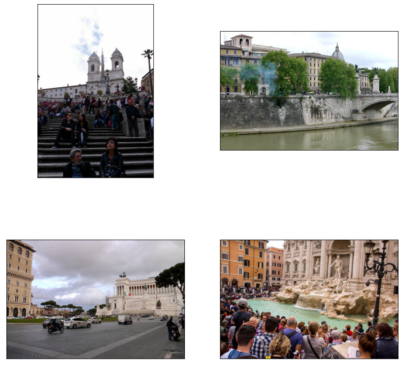

```python
im = []
for x in result['photos']['photo']:
    if x.get('url_c') is not None:
        im.append(io.imread(x.get('url_c')))
    if len(im)>3:
        break
display_images(im)
```

## API Flickr Python

Per semplificare tutto ciò che è stato visto fino adesso è possibile usare una libreria Python che si chiama **flickerapi**.  
La [guida](https://stuvel.eu/flickrapi-doc/) fornisce un codice per potersi autenticare e usare le API di Flickr.

```python
import flickrapi
import webbrowser

api_key = KEY
api_secret = SECRET

flickr = flickrapi.FlickrAPI(api_key, api_secret, format='json')

print('Step 1: authenticate')

# Only do this if we don't have a valid token already
if not flickr.token_valid(perms='read'):

    # Get a request token
    flickr.get_request_token(oauth_callback='oob')

    # Open a browser at the authentication URL. Do this however
    # you want, as long as the user visits that URL.
    authorize_url = flickr.auth_url(perms='read')
    webbrowser.open_new_tab(authorize_url)

    # Get the verifier code from the user. Do this however you
    # want, as long as the user gives the application the code.
    verifier = str(input('Verifier code: '))

    # Trade the request token for an access token
    flickr.get_access_token(verifier)

print('Step 2: use Flickr')
```

```
Step 1: authenticate
Verifier code: 428-179-244
Step 2: use Flickr
```

## Estrazione dati e analisi

In questa fase utilizzeremo le API per estrarre dei dati e analizzarli.  
In particolare, essendo che Flickr è un social media di hosting di immagini, esso molto probabilmente conterrà foto di luoghi famosi in diversi anni.  
Quello che si vuole fare è, innanzitutto, considerare le 3 città italiane che negli anni hanno ospitato il maggior numero di tusristi e facendo qualche ricerca queste sono:

- Roma;
- Milano;
- Venezia.

Di queste località bisogna considerare i luoghi/monumenti più famosi e questi sono reperibili da [TripAdvisor](https://www.tripadvisor.it/). Per estrarre le informazioni da TripAdvisor è stato studiato il DOM della pagina e usando la libreria di Python BeautifulSoup sono stati estratti i 5 luoghi più famosi.  
Una volta ottenuti questi dati, si useranno le API di Flickr per trovare il numero di foto scattate di un luogo X per ogni anno K con $d_s \le K \le d_f$, dove $d_s$ è l'anno di inizio e $d_f$ è l'anno di fine che si vuole analizzare. In particolare, considereremo $d_s = 2012$ e $d_f = 2020$.  
Si vuole verificare se a causa della Pandemia COVID-19, le foto di luoghi/monumenti famosi sono diminuite nel 2020.

La funzione get_timestamp ci permette di trasformare una data nel formato dd/mm/YYYY in **Unix Time**, che sono il numero di secondi trascorsi dal 01/01/1970.

```python
def get_timestamp(stime):
    return time.mktime(datetime.strptime(stime, "%d/%m/%Y").timetuple())
```

La funzione get_famous_places prende in ingresso un url di TripAdvisor e ci restituisce un array contenente i 5 luoghi più famosi.  
Qui sono state fatte due modifiche hard coded: la prima riguarda "Il Cenacolo", anche conosciuto come "L'ultima cena", che non può avere molte foto perché è vietato farle, quindi è stato sotituito con "Chiesa di San Maurizio al Monastero Maggiore"; la seconda riguarda "Colle Palatino" che non è molto frequente tra le immagini reperite su Flickr ed è stato sostituito con "Vaticano".

```python
from bs4 import BeautifulSoup as soup

def get_famous_places(url):
    uClient=uRequest(url)
    page_html = uClient.read()
    page_soup = soup(page_html)
    containers = page_soup.findAll('a',{'class':'_1QKQOve4'})
    containers = containers[:5]
    result = []
    for c in containers:
        name = c.findAll('h2')[0].text
        if name == "Il Cenacolo":
            name = "Chiesa di San Maurizio al Monastero Maggiore"
        if name == "Colle Palatino":
            name = "Vaticano"
        result.append(name)
    return result
```

La funzione get_name_from_url usa le espressioni regolari per estrarre il nome della città direttamente dall'url.

```python
import re

def get_name_from_url(url):
    return re.search("[A-Z]([a-z])+_", url).group()[:-1]
```

La funzione get_info_from_flickr prende in ingresso una lista di URL, l'anno di inizio e l'anno di fine che si vuole analizzare.  
In uscita restituirà un dataframe e le caratteristiche sono:

- Città: nome della città;
- Luogo: nome del luogo/monumento;
- Foto: numero totali di foto trovate;
- Anno: anno in cui sono state scattate.

```python
def get_info_from_flickr(urls, year_start, year_end):
    r = []
    i = 0
    for url in urls:
        city = get_name_from_url(url)
        print(f"Estrazione dati: {city}")
        places = get_famous_places(url)
        year = year_start
        while year <= year_end:
            min_taken_date = int(get_timestamp(f"01/01/{year}"))
            max_taken_date = int(get_timestamp(f"31/12/{year}"))
            for place in places:
                raw_json = flickr.photos.search(text = place, tags = city, extras = "url_c",
                                                min_taken_date = min_taken_date, max_taken_date = max_taken_date)
                result = json.loads(raw_json)
                total_photo = result['photos']['total']
                r.append([city, place, total_photo, year])
            year += 1
        i += 1
        print("--------------------------------------------------------------------\n\n")
    return pd.DataFrame(r, columns = ["Città", "Luogo", "Foto", "Anno"])
```

La funzione draw_plot servirà per disegnare i grafici, che mostreranno per ogni anno quante foto in media sono state scattate in una determinata città. Insieme al grafico saranno visualizzate alcune informazioni utili come:

- L'anno in cui si ha avuto la massima e la minima media di foto scattate;
- Il valore della massima e della minima media di foto scattate;
- La differenza tra la media di foto scattate nel 2019 e la media di foto scattate nel 2020.

```python
import numpy as np

def draw_plot(title, values, names):
    fig, ax = plt.subplots()
    y_pos = np.arange(len(names))
    ax.barh(y_pos, values, align='center')
    ax.set_yticks(y_pos)
    ax.set_yticklabels(names)
    ax.invert_yaxis()
    ax.set_xlabel('Media Foto Annuali')
    ax.set_title(title)
    plt.show()
    print(
          f"Year-Max: {names[values.index(max(values))]},\
          Year-Min: {names[values.index(min(values))]},\
          \n\nVal-Max: {max(values)},\
          Val-Min: {min(values)},\
          \n\nP(2020) - P(2019) = {values[len(values)-1] - values[len(values)-2]}\n\n"
         )
```

La funzione avarage è una funzione di supporto per la funzione extract_info, questa prende in ingresso un dataframe e calcola la media aritmetica di una determinata colonna. Nel nostro caso servirà per calcolare la media delle foto trovate in uno specifico anno.

```python
import statistics as stat

def average(data):
    data["Media Foto Annuali"] = stat.mean([(int(v)) for v in data["Foto"]])
    return data
```

La funzione extract_info prende in ingresso un dataframe e restituisce un altro dataframe contenente le seguenti caratteristiche:

- Città: nome della città;
- Media Foto Annuali: che è un valore che rappresenta la media delle foto che sono state scattate ai luoghi/monumenti famosi in un anno;
- Anno: anno in cui sono state scattate le foto

```python
import pandas as pd

def extract_info(df):
    del df['Luogo']
    grouped = df.groupby(['Città','Anno']).apply(average)
    df = grouped[['Città', 'Media Foto Annuali', 'Anno']]
    df = df.groupby(['Città', 'Anno']).first().reset_index()
    return df
```

info_url è un vettore che contiene i link di TripAdvisor su cui verrà fatto Web Scraping.

```python
info_url = [
    "https://www.tripadvisor.it/Attractions-g187791-Activities-c47-Rome_Lazio.html",
    "https://www.tripadvisor.it/Attractions-g187849-Activities-c47-Milan_Lombardy.html",
    "https://www.tripadvisor.it/Attractions-g187870-Activities-c47-Venice_Veneto.html"
]
```

A questo punto richiamiamo la funzione get_info_from_flickr per ottenere il dataframe e visualizziamo 20 dei suoi elementi.

```python
df = get_info_from_flickr(info_url, 2012, 2020)
print(df.sample(20))
```

```
Estrazione dati: Rome
--------------------------------------------------------------------


Estrazione dati: Milan
--------------------------------------------------------------------


Estrazione dati: Venice
--------------------------------------------------------------------


      Città                                         Luogo  Foto  Anno
46    Milan  Chiesa di San Maurizio al Monastero Maggiore     0  2012
87    Milan                 Galleria Vittorio Emanuele II    23  2020
57    Milan                 Galleria Vittorio Emanuele II   303  2014
7      Rome                                   Foro Romano   738  2013
56    Milan  Chiesa di San Maurizio al Monastero Maggiore     8  2014
55    Milan                               Duomo di Milano   987  2014
112  Venice                         Basilica di San Marco   285  2016
36     Rome                                      Pantheon  2196  2019
97   Venice                         Basilica di San Marco   478  2013
26     Rome                                      Pantheon  6754  2017
118  Venice                               Ponte di Rialto    95  2017
49    Milan                            Castello Sforzesco   550  2012
65    Milan                               Duomo di Milano  1241  2016
3      Rome                                      Colosseo  2665  2012
19     Rome                                      Vaticano  3049  2015
42     Rome                                   Foro Romano   386  2020
89    Milan                            Castello Sforzesco    89  2020
27     Rome                                   Foro Romano   573  2017
85    Milan                               Duomo di Milano   130  2020
101  Venice                              Piazza San Marco  1318  2014
```

Utilizziamo la funzione extract_info per ottenere il dataframe che contiene la media delle foto scattate in una città per un preciso anno e mostriamo 5 esempi.

```python
dfm = extract_info(df)
dfm.sample(5)
```

|  | Città | Anno | Media Foto Annuali |
| --- | --- | --- | --- |
| 6 | Milan | 2018 | 242.0 |
| 19 | Venice | 2013 | 706.2 |
| 11 | Rome | 2014 | 2471.8 |
| 15 | Rome | 2018 | 1404.2 |
| 23 | Venice | 2017 | 364.2 |

La funzione get_info è una funzione di supporto che viene utilizzata dall'istruzione successiva e prende un dataframe che contiene un insieme di elementi che appartengono alla stessa città e richiama la funzione draw_plot.

```python
def get_info(data):
    draw_plot(
        data["Città"].tolist()[0],
        data["Media Foto Annuali"].tolist(),
        data["Anno"].tolist()
    )
```

Effettuiamo il groupby del dataframe ottenuto dalla funzione extract_info e con apply utilizziamo una funzione lambda che prende in ingresso tanti dataframe quante sono le città e per ognuno di essi applica la funzione get_info.

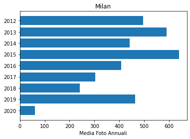

```
Year-Max: 2015,          Year-Min: 2020,

Val-Max: 639.2,          Val-Min: 61.0,

P(2020) - P(2019) = -402.8
```

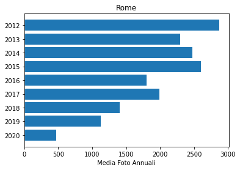

```
Year-Max: 2012,          Year-Min: 2020,

Val-Max: 2866.4,          Val-Min: 467.2,

P(2020) - P(2019) = -658.8
```

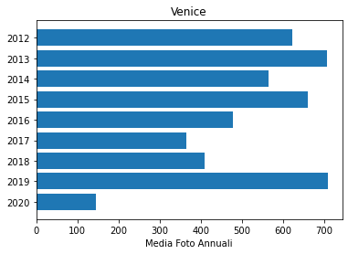

```
Year-Max: 2019,          Year-Min: 2020,

Val-Max: 707.8,          Val-Min: 146.0,

P(2020) - P(2019) = -561.8
```

```python
dfm.groupby('Città').apply(lambda data: get_info(data))
```

Dai grafici e dai dati ottenuti possiamo osservare come il social media, in media negli anni, ha avuto molte immagini riguardanti i luoghi/monumenti reperiti da TripAdvisor, ma proprio nel 2020 questa media è molto bassa ed è proprio quello che ci aspettavamo data la Pandemia COVID-19. Infatti, sottraendo la media del 2019 a quella del 2020 otteniamo sempre un numero negativo, questo ci dà conferma della diminuzione degli spostamenti nell'anno 2020.

## Conclusione

L'utilizzo delle API di Flickr è abbastanza complesso, più che altro per l'intero processo di richiesta di un token. Per risolvere questo problema, ci sono dei wrapper, come quello visto in Python, che ci permettono di semplificare di molto le varie operazioni.  
Una volta aver ricevuto il token siamo in grado di estrarre molte informazioni dal social media e possiamo definirlo come una sorta di database illimitato di immagini pronte all'uso.

## Riconoscimenti

Questo tutorial è stato originariamente creato da Luigi Seminara, studente del corso di Social Media Management AA. 2020/2021 e in seguito adattato leggermente dal docente per fornire un esempio di tutorial per gli studenti del corso.